# Assignment 2

The telecom company wants to find the factors influence the churn and also monthly charges. Use your EDA techniques and statistical hypothesis techniques and find the factors which influences the churn and monthly charges.

```python
import pandas as pd
import numpy as np
import seaborn as sns
import matplotlib.pyplot as plt
```

```python
df = pd.read_excel('Stats_assignment_2.xlsx')
df.head()
```

|  | customerID | gender | SeniorCitizen | Partner | Dependents | tenure | PhoneService | OnlineBackup | TechSupport | StreamingTV | Contract | PaperlessBilling | PaymentMethod | MonthlyCharges | Churn |
| --- | --- | --- | --- | --- | --- | --- | --- | --- | --- | --- | --- | --- | --- | --- | --- |
| 0 | 7590-VHVEG | Female | 0 | Yes | No | 1 | No | Yes | No | No | Month-to-month | Yes | Electronic check | 29.85 | No |
| 1 | 5575-GNVDE | Male | 0 | No | No | 34 | Yes | No | No | No | One year | No | Mailed check | 56.95 | No |
| 2 | 3668-QPYBK | Male | 0 | No | No | 2 | Yes | Yes | No | No | Month-to-month | Yes | Mailed check | 53.85 | Yes |
| 3 | 7795-CFOCW | Male | 0 | No | No | 45 | No | No | Yes | No | One year | No | Bank transfer (automatic) | 42.30 | No |
| 4 | 9237-HQITU | Female | 0 | No | No | 2 | Yes | No | No | No | Month-to-month | Yes | Electronic check | 70.70 | Yes |

```python
df.info()
```

```
<class 'pandas.core.frame.DataFrame'>
RangeIndex: 7043 entries, 0 to 7042
Data columns (total 15 columns):
 #   Column            Non-Null Count  Dtype
---  ------            --------------  -----
 0   customerID        7043 non-null   object
 1   gender            7043 non-null   object
 2   SeniorCitizen     7043 non-null   int64
 3   Partner           7043 non-null   object
 4   Dependents        7043 non-null   object
 5   tenure            7043 non-null   int64
 6   PhoneService      7043 non-null   object
 7   OnlineBackup      7043 non-null   object
 8   TechSupport       7043 non-null   object
 9   StreamingTV       7043 non-null   object
 10  Contract          7043 non-null   object
 11  PaperlessBilling  7043 non-null   object
 12  PaymentMethod     7043 non-null   object
 13  MonthlyCharges    7043 non-null   float64
 14  Churn             7043 non-null   object
dtypes: float64(1), int64(2), object(12)
memory usage: 825.5+ KB
```

```python
df.describe().T
```

|  | count | mean | std | min | 25% | 50% | 75% | max |
| --- | --- | --- | --- | --- | --- | --- | --- | --- |
| SeniorCitizen | 7043.0 | 0.162147 | 0.368612 | 0.00 | 0.0 | 0.00 | 0.00 | 1.00 |
| tenure | 7043.0 | 32.371149 | 24.559481 | 0.00 | 9.0 | 29.00 | 55.00 | 72.00 |
| MonthlyCharges | 7043.0 | 64.761692 | 30.090047 | 18.25 | 35.5 | 70.35 | 89.85 | 118.75 |

```python
df.astype('object').describe().T
```

|  | count | unique | top | freq |
| --- | --- | --- | --- | --- |
| customerID | 7043 | 7043 | 2223-GDSHL | 1 |
| gender | 7043 | 2 | Male | 3555 |
| SeniorCitizen | 7043 | 2 | 0 | 5901 |
| Partner | 7043 | 2 | No | 3641 |
| Dependents | 7043 | 2 | No | 4933 |
| tenure | 7043 | 73 | 1 | 613 |
| PhoneService | 7043 | 2 | Yes | 6361 |
| OnlineBackup | 7043 | 3 | No | 3088 |
| TechSupport | 7043 | 3 | No | 3473 |
| StreamingTV | 7043 | 3 | No | 2810 |
| Contract | 7043 | 3 | Month-to-month | 3875 |
| PaperlessBilling | 7043 | 2 | Yes | 4171 |
| PaymentMethod | 7043 | 4 | Electronic check | 2365 |
| MonthlyCharges | 7043.0 | 1585.0 | 20.05 | 61.0 |
| Churn | 7043 | 2 | No | 5174 |

```python
df.isnull().sum()
```

```
customerID          0
gender              0
SeniorCitizen       0
Partner             0
Dependents          0
tenure              0
PhoneService        0
OnlineBackup        0
TechSupport         0
StreamingTV         0
Contract            0
PaperlessBilling    0
PaymentMethod       0
MonthlyCharges      0
Churn               0
dtype: int64
```

```python
df.duplicated().sum()
```

```
0
```

```python
df1 = df.copy()
df1.head()
```

|  | customerID | gender | SeniorCitizen | Partner | Dependents | tenure | PhoneService | OnlineBackup | TechSupport | StreamingTV | Contract | PaperlessBilling | PaymentMethod | MonthlyCharges | Churn |
| --- | --- | --- | --- | --- | --- | --- | --- | --- | --- | --- | --- | --- | --- | --- | --- |
| 0 | 7590-VHVEG | Female | 0 | Yes | No | 1 | No | Yes | No | No | Month-to-month | Yes | Electronic check | 29.85 | No |
| 1 | 5575-GNVDE | Male | 0 | No | No | 34 | Yes | No | No | No | One year | No | Mailed check | 56.95 | No |
| 2 | 3668-QPYBK | Male | 0 | No | No | 2 | Yes | Yes | No | No | Month-to-month | Yes | Mailed check | 53.85 | Yes |
| 3 | 7795-CFOCW | Male | 0 | No | No | 45 | No | No | Yes | No | One year | No | Bank transfer (automatic) | 42.30 | No |
| 4 | 9237-HQITU | Female | 0 | No | No | 2 | Yes | No | No | No | Month-to-month | Yes | Electronic check | 70.70 | Yes |

```python
df1.drop(columns=['customerID'],axis=1,inplace=True)
df1.head()
```

|  | gender | SeniorCitizen | Partner | Dependents | tenure | PhoneService | OnlineBackup | TechSupport | StreamingTV | Contract | PaperlessBilling | PaymentMethod | MonthlyCharges | Churn |
| --- | --- | --- | --- | --- | --- | --- | --- | --- | --- | --- | --- | --- | --- | --- |
| 0 | Female | 0 | Yes | No | 1 | No | Yes | No | No | Month-to-month | Yes | Electronic check | 29.85 | No |
| 1 | Male | 0 | No | No | 34 | Yes | No | No | No | One year | No | Mailed check | 56.95 | No |
| 2 | Male | 0 | No | No | 2 | Yes | Yes | No | No | Month-to-month | Yes | Mailed check | 53.85 | Yes |
| 3 | Male | 0 | No | No | 45 | No | No | Yes | No | One year | No | Bank transfer (automatic) | 42.30 | No |
| 4 | Female | 0 | No | No | 2 | Yes | No | No | No | Month-to-month | Yes | Electronic check | 70.70 | Yes |

```python
df['Churn'].value_counts(normalize=True).mul(100).round(2)
```

```
No     73.46
Yes    26.54
Name: Churn, dtype: float64
```

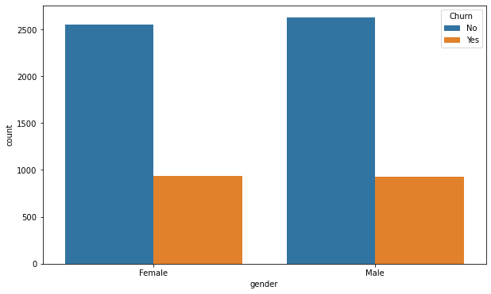

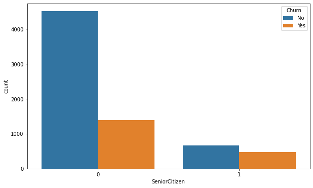

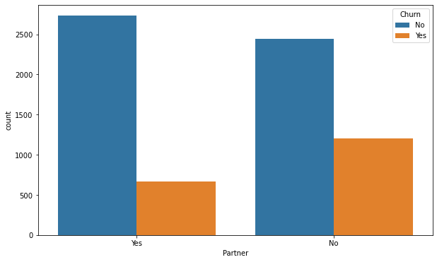

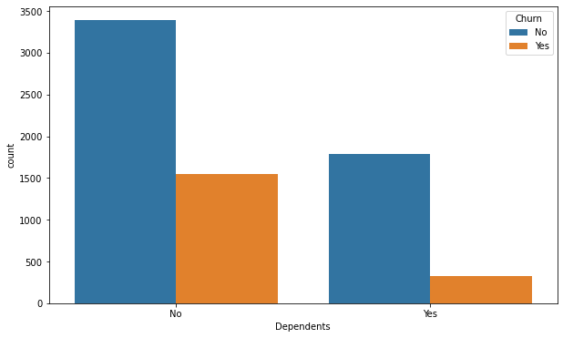

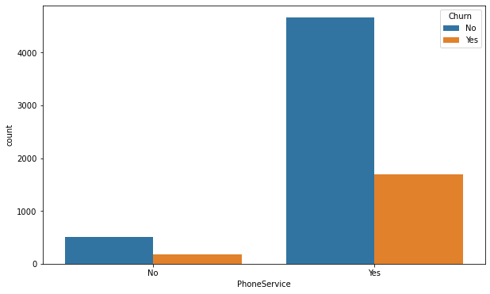

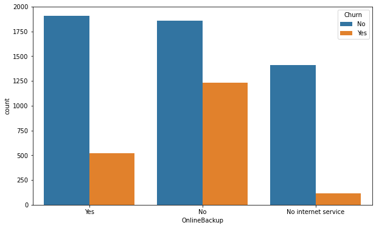

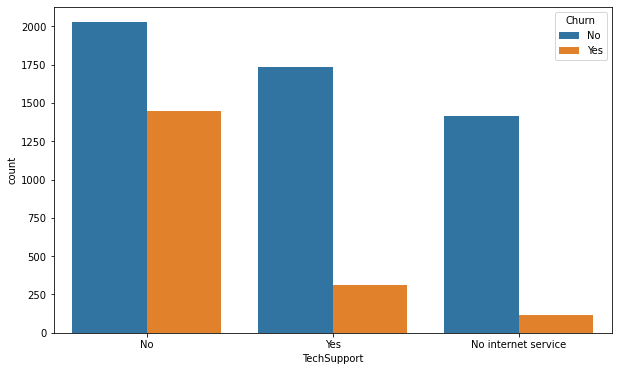

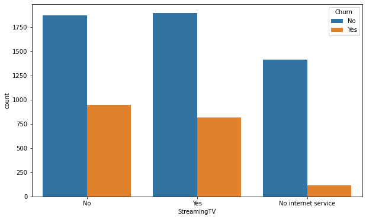

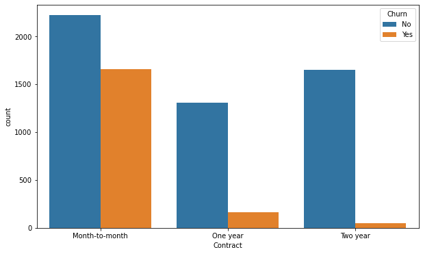

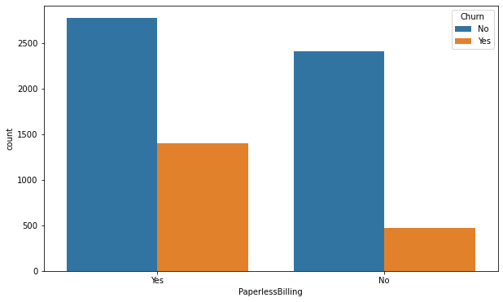

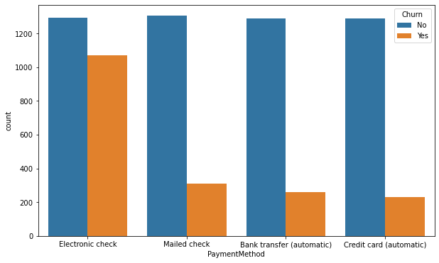

```python
for i, predictor in enumerate(df1.drop(columns=['MonthlyCharges','Churn','tenure'])):
    plt.figure(i)
    fig, ax = plt.subplots(figsize=(10,6))
    sns.countplot(x=predictor,hue='Churn',data=df1,ax=ax)
    plt.show()
```

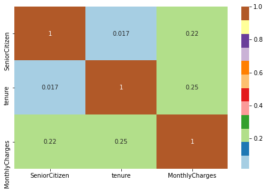

```python
plt.figure(figsize=(8,5))
sns.heatmap(df1.corr(),annot=True,cmap='Paired')
```

# Hypothesis Test

Because of most of the data is categorical we are using chi2-contegency test to know the relation ship of depndent variabel "Churn" against all other independent variables in the data set

```python
import scipy.stats as stats
from scipy.stats import chi2_contingency
```

```python
pd.crosstab(df1['Churn'],df1['gender'])
```

| gender Churn | Female | Male |
| --- | --- | --- |
| No | 2549 | 2625 |
| Yes | 939 | 930 |

chi2_contingency test will give 4 values,they are, 1.Chi-square value 2.p-value 3.degrees of freedom (n-1) 4.expected frequencies as an array by using P-Value we will accept or reject H0 nullhypothesis if p-value > alpha(0.05) accept Null hypotesis else reject H0/acceptH1 here by using P-Value we are going to conclude the relationship between dependent and independent variable

# H0:- There is no relation ship b/w depndent variabel "Churn" and independent variable

# H1:- There is relation ship b/w depndent variabel "Churn" and independent variable

```python
chi2_contingency(pd.crosstab(df1.Churn,df1.gender))
```

```
(0.4840828822091383,
 0.48657873605618596,
 1,
 array([[2562.38989067, 2611.61010933],
        [ 925.61010933,  943.38989067]]))
```

```python
chi2_contingency(pd.crosstab(df1.Churn,df1.SeniorCitizen))
```

```
(159.42630036838742,
 1.510066805092378e-36,
 1,
 array([[4335.05239245,  838.94760755],
        [1565.94760755,  303.05239245]]))
```

```python
chi2_contingency(pd.crosstab(df1.Churn,df1.Partner))
```

```
(158.7333820309922,
 2.1399113440759935e-36,
 1,
 array([[2674.78830044, 2499.21169956],
        [ 966.21169956,  902.78830044]]))
```

```python
chi2_contingency(pd.crosstab(df1.Churn,df1.Dependents))
```

```
(189.12924940423474,
 4.9249216612154196e-43,
 1,
 array([[3623.93042737, 1550.06957263],
        [1309.06957263,  559.93042737]]))
```

```python
chi2_contingency(pd.crosstab(df1.Churn,df1.tenure))
```

[output not shown]

```python
chi2_contingency(pd.crosstab(df1.Churn,df1.PhoneService))
```

```
(0.9150329892546948,
 0.3387825358066928,
 1,
 array([[ 501.01774812, 4672.98225188],
        [ 180.98225188, 1688.01774812]]))
```

```python
chi2_contingency(pd.crosstab(df1.Churn,df1.OnlineBackup))
```

```
(601.8127901134089,
 2.0797592160865457e-131,
 2,
 array([[2268.53783899, 1121.04557717, 1784.41658384],
        [ 819.46216101,  404.95442283,  644.58341616]]))
```

```python
chi2_contingency(pd.crosstab(df1.Churn,df1.TechSupport))
```

```
(828.1970684587393,
 1.4430840279999813e-180,
 2,
 array([[2551.37043873, 1121.04557717, 1501.5839841 ],
        [ 921.62956127,  404.95442283,  542.4160159 ]]))
```

```python
chi2_contingency(pd.crosstab(df1.Churn,df1.StreamingTV))
```

```
(374.20394331098134,
 5.528994485739024e-82,
 2,
 array([[2064.31066307, 1121.04557717, 1988.64375976],
        [ 745.68933693,  404.95442283,  718.35624024]]))
```

```python
chi2_contingency(pd.crosstab(df1.Churn,df1.Contract))
```

```
(1184.5965720837926,
 5.863038300673391e-258,
 2,
 array([[2846.69175067, 1082.11018032, 1245.198069  ],
        [1028.30824933,  390.88981968,  449.801931  ]]))
```

```python
chi2_contingency(pd.crosstab(df1.Churn,df1.PaperlessBilling))
```

```
(258.27764906707307,
 4.073354668665985e-58,
 1,
 array([[2109.85773108, 3064.14226892],
        [ 762.14226892, 1106.85773108]]))
```

```python
chi2_contingency(pd.crosstab(df1.Churn,df1.PaymentMethod))
```

```
(648.1423274814,
 3.6823546520097993e-140,
 3,
 array([[1134.26891949, 1118.10705665, 1737.40025557, 1184.22376828],
        [ 409.73108051,  403.89294335,  627.59974443,  427.77623172]]))
```

```python
chi2_contingency(pd.crosstab(df1.Churn,df1.MonthlyCharges))
```

```
(2123.609129997958,
 1.8852727784254426e-18,
 1584,
 array([[0.73463013, 0.73463013, 0.73463013, ..., 1.46926026, 0.73463013,
         0.73463013],
        [0.26536987, 0.26536987, 0.26536987, ..., 0.53073974, 0.26536987,
         0.26536987]]))
```

In above we observe that p-value is >alpha only for Gender and PhoneServices here we conclde that only for Gender and PhoneServices doesn't have relationship with churn Accept H0: null hypothesis for Gender and PhoneServices

```python
# Because there is no co-relation b/w Gender and PhoneServices we are Dropping the columns Gender and PhoneServices
df1.drop(columns=['gender','PhoneService'],axis=1,inplace=True)
```

```python
#df1= df1.replace(['No','Yes'],[0,1])
#df1['Churn'] = df1['Churn'].map({'No':0,'Yes':1})
```

```python
#Create a label encoder object
from sklearn.preprocessing import LabelEncoder, OneHotEncoder

le = LabelEncoder()
# Label Encoding will be used for columns with 2 or less unique values
le_count = 0
for col in df1.columns[1:]:
    if df1[col].dtype == 'object':
        if len(list(df1[col].unique())) <= 2:
            le.fit(df1[col])
            df1[col] = le.transform(df1[col])
            le_count += 1
print('{} columns were label encoded.'.format(le_count))
```

```
4 columns were label encoded.
```

```python
df1.head()
```

|  | SeniorCitizen | Partner | Dependents | tenure | OnlineBackup | TechSupport | StreamingTV | Contract | PaperlessBilling | PaymentMethod | MonthlyCharges | Churn |
| --- | --- | --- | --- | --- | --- | --- | --- | --- | --- | --- | --- | --- |
| 0 | 0 | 1 | 0 | 1 | Yes | No | No | Month-to-month | 1 | Electronic check | 29.85 | 0 |
| 1 | 0 | 0 | 0 | 34 | No | No | No | One year | 0 | Mailed check | 56.95 | 0 |
| 2 | 0 | 0 | 0 | 2 | Yes | No | No | Month-to-month | 1 | Mailed check | 53.85 | 1 |
| 3 | 0 | 0 | 0 | 45 | No | Yes | No | One year | 0 | Bank transfer (automatic) | 42.30 | 0 |
| 4 | 0 | 0 | 0 | 2 | No | No | No | Month-to-month | 1 | Electronic check | 70.70 | 1 |

```python
df1.Contract.value_counts()
```

```
Month-to-month    3875
Two year          1695
One year          1473
Name: Contract, dtype: int64
```

```python
df1.OnlineBackup.value_counts()
```

```
No                     3088
Yes                    2429
No internet service    1526
Name: OnlineBackup, dtype: int64
```

```python
 df1.PaymentMethod.value_counts()
```

```
Electronic check             2365
Mailed check                 1612
Bank transfer (automatic)    1544
Credit card (automatic)      1522
Name: PaymentMethod, dtype: int64
```

```python
df1= df1.replace(['No','Yes'],[0,1])
```

```python
df1.OnlineBackup.value_counts()
```

```
0                      3088
1                      2429
No internet service    1526
Name: OnlineBackup, dtype: int64
```

```python
df1.head()
```

|  | SeniorCitizen | Partner | Dependents | tenure | OnlineBackup | TechSupport | StreamingTV | Contract | PaperlessBilling | PaymentMethod | MonthlyCharges | Churn |
| --- | --- | --- | --- | --- | --- | --- | --- | --- | --- | --- | --- | --- |
| 0 | 0 | 1 | 0 | 1 | 1 | 0 | 0 | Month-to-month | 1 | Electronic check | 29.85 | 0 |
| 1 | 0 | 0 | 0 | 34 | 0 | 0 | 0 | One year | 0 | Mailed check | 56.95 | 0 |
| 2 | 0 | 0 | 0 | 2 | 1 | 0 | 0 | Month-to-month | 1 | Mailed check | 53.85 | 1 |
| 3 | 0 | 0 | 0 | 45 | 0 | 1 | 0 | One year | 0 | Bank transfer (automatic) | 42.30 | 0 |
| 4 | 0 | 0 | 0 | 2 | 0 | 0 | 0 | Month-to-month | 1 | Electronic check | 70.70 | 1 |

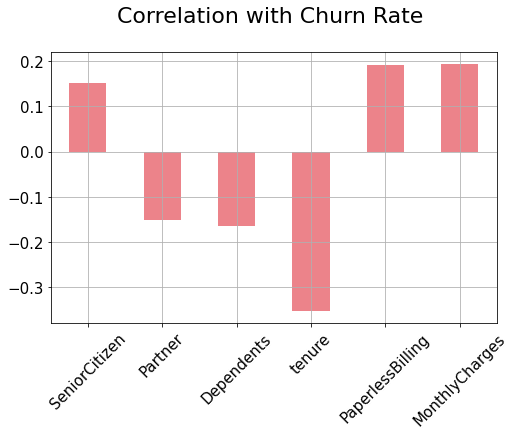

```python
df2 = df1[['SeniorCitizen', 'Partner', 'Dependents','tenure','OnlineBackup','TechSupport',
          'StreamingTV','Contract','PaperlessBilling','PaymentMethod', 'MonthlyCharges']]

correlations = df2.corrwith(df1.Churn)
correlations = correlations[correlations!=1]
correlations.plot.bar(
        figsize = (8, 5),
        fontsize = 15,
        color = '#ec838a',
        rot = 45, grid = True)
plt.title('Correlation with Churn Rate \n',
horizontalalignment="center", fontstyle = "normal",
fontsize = "22", fontfamily = "sans-serif")
```

```python
df1= pd.get_dummies(df1)
df1.head()
```

|  | SeniorCitizen | Partner | Dependents | tenure | PaperlessBilling | MonthlyCharges | Churn | OnlineBackup_0 | OnlineBackup_1 | OnlineBackup_No internet service | ... | StreamingTV_0 | StreamingTV_1 | StreamingTV_No internet service | Contract_Month-to-month | Contract_One year | Contract_Two year | PaymentMethod_Bank transfer (automatic) | PaymentMethod_Credit card (automatic) | PaymentMethod_Electronic check | PaymentMethod_Mailed check |
| --- | --- | --- | --- | --- | --- | --- | --- | --- | --- | --- | --- | --- | --- | --- | --- | --- | --- | --- | --- | --- | --- |
| 0 | 0 | 1 | 0 | 1 | 1 | 29.85 | 0 | 0 | 1 | 0 | ... | 1 | 0 | 0 | 1 | 0 | 0 | 0 | 0 | 1 | 0 |
| 1 | 0 | 0 | 0 | 34 | 0 | 56.95 | 0 | 1 | 0 | 0 | ... | 1 | 0 | 0 | 0 | 1 | 0 | 0 | 0 | 0 | 1 |
| 2 | 0 | 0 | 0 | 2 | 1 | 53.85 | 1 | 0 | 1 | 0 | ... | 1 | 0 | 0 | 1 | 0 | 0 | 0 | 0 | 0 | 1 |
| 3 | 0 | 0 | 0 | 45 | 0 | 42.30 | 0 | 1 | 0 | 0 | ... | 1 | 0 | 0 | 0 | 1 | 0 | 1 | 0 | 0 | 0 |
| 4 | 0 | 0 | 0 | 2 | 1 | 70.70 | 1 | 1 | 0 | 0 | ... | 1 | 0 | 0 | 1 | 0 | 0 | 0 | 0 | 1 | 0 |

5 rows × 23 columns

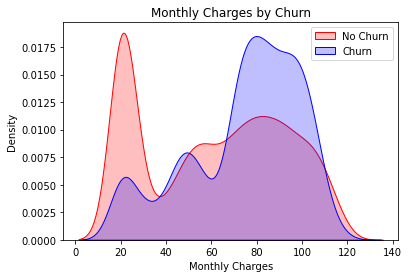

```python
## measuring a Churn by Monthly Charges
mtch = sns.kdeplot(df1.MonthlyCharges[(df1['Churn']==0)],color='red',shade=True)
mtch = sns.kdeplot(df1.MonthlyCharges[(df1['Churn']==1)],color='blue',shade=True)
mtch.legend(['No Churn','Churn'],loc='upper right')
mtch.set_xlabel('Monthly Charges')
mtch.set_ylabel('Density')
mtch.set_title('Monthly Charges by Churn')
plt.show()
```

```python
df1.cov()
```

|  | SeniorCitizen | Partner | Dependents | tenure | PaperlessBilling | MonthlyCharges | Churn | OnlineBackup_0 | OnlineBackup_1 | OnlineBackup_No internet service | ... | StreamingTV_0 | StreamingTV_1 | StreamingTV_No internet service | Contract_Month-to-month | Contract_One year | Contract_Two year | PaymentMethod_Bank transfer (automatic) | PaymentMethod_Credit card (automatic) | PaymentMethod_Electronic check | PaymentMethod_Mailed check |
| --- | --- | --- | --- | --- | --- | --- | --- | --- | --- | --- | --- | --- | --- | --- | --- | --- | --- | --- | --- | --- | --- |
| SeniorCitizen | 0.135875 | 0.003036 | -0.035662 | 0.149978 | 0.028356 | 2.442062 | 0.024559 | 0.016088 | 0.011665 | -0.027753 | ... | 0.008856 | 0.018896 | -0.027753 | 0.025374 | -0.006936 | -0.018438 | -0.002464 | -0.003662 | 0.029895 | -0.023769 |
| Partner | 0.003036 | 0.249748 | 0.103635 | 4.660232 | -0.003654 | 1.456344 | -0.033199 | -0.033741 | 0.033615 | 0.000127 | ... | -0.030435 | 0.030308 | 0.000127 | -0.069831 | 0.016827 | 0.053005 | 0.022891 | 0.016874 | -0.019792 | -0.019973 |
| Dependents | -0.035662 | 0.103635 | 0.209865 | 1.796915 | -0.025076 | -1.569926 | -0.033219 | -0.031543 | 0.005155 | 0.026389 | ... | -0.022699 | -0.003690 | 0.026389 | -0.052812 | 0.012739 | 0.040074 | 0.009860 | 0.011364 | -0.032594 | 0.011369 |
| tenure | 0.149978 | 4.660232 | 1.796915 | 603.168108 | 0.074260 | 183.196987 | -3.819750 | -3.810864 | 4.206118 | -0.395253 | ... | -2.947164 | 3.342417 | -0.395253 | -7.887845 | 2.023473 | 5.864371 | 2.474431 | 2.355455 | -2.416894 | -2.412992 |
| PaperlessBilling | 0.028356 | -0.003654 | -0.025076 | 0.074260 | 0.241530 | 5.207580 | 0.041628 | 0.035392 | 0.029608 | -0.065000 | ... | 0.011483 | 0.053516 | -0.065000 | 0.041345 | -0.010272 | -0.031072 | -0.003321 | -0.002749 | 0.048481 | -0.042411 |
| MonthlyCharges | 2.442062 | 1.456344 | -1.569926 | 183.196987 | 5.207580 | 905.410934 | 2.569050 | 3.146896 | 6.319092 | -9.465989 | ... | 0.249793 | 9.216195 | -9.465989 | 0.900680 | 0.060015 | -0.960696 | 0.533002 | 0.378380 | 3.860210 | -4.771592 |
| Churn | 0.024559 | -0.033199 | -0.033219 | -3.819750 | 0.041628 | 2.569050 | 0.194976 | 0.058724 | -0.017265 | -0.041459 | ... | 0.027877 | 0.013582 | -0.041459 | 0.088993 | -0.031936 | -0.057058 | -0.021547 | -0.024410 | 0.062965 | -0.017009 |
| OnlineBackup_0 | 0.016088 | -0.033741 | -0.031543 | -3.810864 | 0.035392 | 3.146896 | 0.058724 | 0.246247 | -0.151235 | -0.095012 | ... | 0.076961 | 0.018051 | -0.095012 | 0.083642 | -0.022556 | -0.061087 | -0.016752 | -0.017938 | 0.055533 | -0.020844 |
| OnlineBackup_1 | 0.011665 | 0.033615 | 0.005155 | 4.206118 | 0.029608 | 6.319092 | -0.017265 | -0.151235 | 0.225970 | -0.074736 | ... | 0.009498 | 0.065238 | -0.074736 | -0.038826 | 0.016187 | 0.022639 | 0.017112 | 0.017763 | -0.000092 | -0.034784 |
| OnlineBackup_No internet service | -0.027753 | 0.000127 | 0.026389 | -0.395253 | -0.065000 | -9.465989 | -0.041459 | -0.095012 | -0.074736 | 0.169748 | ... | -0.086458 | -0.083289 | 0.169748 | -0.044816 | 0.006368 | 0.038447 | -0.000360 | 0.000175 | -0.055442 | 0.055628 |
| TechSupport_0 | 0.037896 | -0.027346 | -0.039544 | -3.218972 | 0.056550 | 4.845526 | 0.074463 | 0.095607 | 0.011251 | -0.106858 | ... | 0.084969 | 0.021889 | -0.106858 | 0.109228 | -0.024049 | -0.085179 | -0.018655 | -0.022085 | 0.080060 | -0.039321 |
| TechSupport_1 | -0.010143 | 0.027220 | 0.013156 | 3.614225 | 0.008450 | 4.620463 | -0.033004 | -0.000595 | 0.063485 | -0.062890 | ... | 0.001490 | 0.061400 | -0.062890 | -0.064412 | 0.017681 | 0.046731 | 0.019015 | 0.021910 | -0.024619 | -0.016306 |
| TechSupport_No internet service | -0.027753 | 0.000127 | 0.026389 | -0.395253 | -0.065000 | -9.465989 | -0.041459 | -0.095012 | -0.074736 | 0.169748 | ... | -0.086458 | -0.083289 | 0.169748 | -0.044816 | 0.006368 | 0.038447 | -0.000360 | 0.000175 | -0.055442 | 0.055628 |
| StreamingTV_0 | 0.008856 | -0.030435 | -0.022699 | -2.947164 | 0.011483 | 0.249793 | 0.027877 | 0.076961 | 0.009498 | -0.086458 | ... | 0.239829 | -0.153370 | -0.086458 | 0.071991 | -0.018559 | -0.053432 | -0.008949 | -0.008271 | 0.022212 | -0.004992 |
| StreamingTV_1 | 0.018896 | 0.030308 | -0.003690 | 3.342417 | 0.053516 | 9.216195 | 0.013582 | 0.018051 | 0.065238 | -0.083289 | ... | -0.153370 | 0.236659 | -0.083289 | -0.027175 | 0.012191 | 0.014985 | 0.009310 | 0.008096 | 0.033230 | -0.050636 |
| StreamingTV_No internet service | -0.027753 | 0.000127 | 0.026389 | -0.395253 | -0.065000 | -9.465989 | -0.041459 | -0.095012 | -0.074736 | 0.169748 | ... | -0.086458 | -0.083289 | 0.169748 | -0.044816 | 0.006368 | 0.038447 | -0.000360 | 0.000175 | -0.055442 | 0.055628 |
| Contract_Month-to-month | 0.025374 | -0.069831 | -0.052812 | -7.887845 | 0.041345 | 0.900680 | 0.088993 | 0.083642 | -0.038826 | -0.044816 | ... | 0.071991 | -0.027175 | -0.044816 | 0.247516 | -0.115086 | -0.132430 | -0.036992 | -0.041805 | 0.077932 | 0.000865 |
| Contract_One year | -0.006936 | 0.016827 | 0.012739 | 2.023473 | -0.010272 | 0.060015 | -0.031936 | -0.022556 | 0.016187 | 0.006368 | ... | -0.018559 | 0.012191 | 0.006368 | -0.115086 | 0.165426 | -0.050341 | 0.009668 | 0.011315 | -0.020964 | -0.000020 |
| Contract_Two year | -0.018438 | 0.053005 | 0.040074 | 5.864371 | -0.031072 | -0.960696 | -0.057058 | -0.061087 | 0.022639 | 0.038447 | ... | -0.053432 | 0.014985 | 0.038447 | -0.132430 | -0.050341 | 0.182771 | 0.027324 | 0.030490 | -0.056968 | -0.000845 |
| PaymentMethod_Bank transfer (automatic) | -0.002464 | 0.022891 | 0.009860 | 2.474431 | -0.003321 | 0.533002 | -0.021547 | -0.016752 | 0.017112 | -0.000360 | ... | -0.008949 | 0.009310 | -0.000360 | -0.036992 | 0.009668 | 0.027324 | 0.171190 | -0.047381 | -0.073625 | -0.050183 |
| PaymentMethod_Credit card (automatic) | -0.003662 | 0.016874 | 0.011364 | 2.355455 | -0.002749 | 0.378380 | -0.024410 | -0.017938 | 0.017763 | 0.000175 | ... | -0.008271 | 0.008096 | 0.000175 | -0.041805 | 0.011315 | 0.030490 | -0.047381 | 0.169425 | -0.072576 | -0.049468 |
| PaymentMethod_Electronic check | 0.029895 | -0.019792 | -0.032594 | -2.416894 | 0.048481 | 3.860210 | 0.062965 | 0.055533 | -0.000092 | -0.055442 | ... | 0.022212 | 0.033230 | -0.055442 | 0.077932 | -0.020964 | -0.056968 | -0.073625 | -0.072576 | 0.223068 | -0.076867 |
| PaymentMethod_Mailed check | -0.023769 | -0.019973 | 0.011369 | -2.412992 | -0.042411 | -4.771592 | -0.017009 | -0.020844 | -0.034784 | 0.055628 | ... | -0.004992 | -0.050636 | 0.055628 | 0.000865 | -0.000020 | -0.000845 | -0.050183 | -0.049468 | -0.076867 | 0.176519 |

23 rows × 23 columns

```python
df1.corr(method='spearman')
```

|  | SeniorCitizen | Partner | Dependents | tenure | PaperlessBilling | MonthlyCharges | Churn | OnlineBackup_0 | OnlineBackup_1 | OnlineBackup_No internet service | ... | StreamingTV_0 | StreamingTV_1 | StreamingTV_No internet service | Contract_Month-to-month | Contract_One year | Contract_Two year | PaymentMethod_Bank transfer (automatic) | PaymentMethod_Credit card (automatic) | PaymentMethod_Electronic check | PaymentMethod_Mailed check |
| --- | --- | --- | --- | --- | --- | --- | --- | --- | --- | --- | --- | --- | --- | --- | --- | --- | --- | --- | --- | --- | --- |
| SeniorCitizen | 1.000000 | 0.016479 | -0.211185 | 0.018556 | 0.156530 | 0.221067 | 0.150889 | 0.087952 | 0.066572 | -0.182742 | ... | 0.049062 | 0.105378 | -0.182742 | 0.138360 | -0.046262 | -0.117000 | -0.016159 | -0.024135 | 0.171718 | -0.153477 |
| Partner | 0.016479 | 1.000000 | 0.452676 | 0.384931 | -0.014877 | 0.108463 | -0.150448 | -0.136058 | 0.141498 | 0.000615 | ... | -0.124357 | 0.124666 | 0.000615 | -0.280865 | 0.082783 | 0.248091 | 0.110706 | 0.082029 | -0.083852 | -0.095125 |
| Dependents | -0.211185 | 0.452676 | 1.000000 | 0.164175 | -0.111377 | -0.107011 | -0.164221 | -0.138756 | 0.023671 | 0.139812 | ... | -0.101176 | -0.016558 | 0.139812 | -0.231720 | 0.068368 | 0.204613 | 0.052021 | 0.060267 | -0.150642 | 0.059071 |
| tenure | 0.018556 | 0.384931 | 0.164175 | 1.000000 | 0.007695 | 0.276417 | -0.367062 | -0.311179 | 0.360032 | -0.040604 | ... | -0.248477 | 0.284523 | -0.040604 | -0.641399 | 0.212250 | 0.544480 | 0.246443 | 0.236579 | -0.209206 | -0.239293 |
| PaperlessBilling | 0.156530 | -0.014877 | -0.111377 | 0.007695 | 1.000000 | 0.345994 | 0.191825 | 0.145120 | 0.126735 | -0.321013 | ... | 0.047712 | 0.223841 | -0.321013 | 0.169096 | -0.051391 | -0.147889 | -0.016332 | -0.013589 | 0.208865 | -0.205398 |
| MonthlyCharges | 0.221067 | 0.108463 | -0.107011 | 0.276417 | 0.345994 | 1.000000 | 0.184743 | 0.173048 | 0.435682 | -0.711107 | ... | -0.040297 | 0.642814 | -0.711107 | 0.039470 | 0.008941 | -0.054438 | 0.045927 | 0.033042 | 0.263802 | -0.374151 |
| Churn | 0.150889 | -0.150448 | -0.164221 | -0.367062 | 0.191825 | 0.184743 | 1.000000 | 0.268005 | -0.082255 | -0.227890 | ... | 0.128916 | 0.063228 | -0.227890 | 0.405103 | -0.177820 | -0.302253 | -0.117937 | -0.134302 | 0.301919 | -0.091683 |
| OnlineBackup_0 | 0.087952 | -0.136058 | -0.138756 | -0.311179 | 0.145120 | 0.173048 | 0.268005 | 1.000000 | -0.641122 | -0.464720 | ... | 0.316689 | 0.074776 | -0.464720 | 0.338796 | -0.111755 | -0.287944 | -0.081590 | -0.087822 | 0.236947 | -0.099975 |
| OnlineBackup_1 | 0.066572 | 0.141498 | 0.023671 | 0.360032 | 0.126735 | 0.435682 | -0.082255 | -0.641122 | 1.000000 | -0.381593 | ... | 0.040799 | 0.282106 | -0.381593 | -0.164172 | 0.083722 | 0.111400 | 0.087004 | 0.090785 | -0.000408 | -0.174164 |
| OnlineBackup_No internet service | -0.182742 | 0.000615 | 0.139812 | -0.040604 | -0.321013 | -0.711107 | -0.227890 | -0.464720 | -0.381593 | 1.000000 | ... | -0.428504 | -0.415552 | 1.000000 | -0.218639 | 0.038004 | 0.218278 | -0.002113 | 0.001030 | -0.284917 | 0.321361 |
| TechSupport_0 | 0.205620 | -0.109443 | -0.172645 | -0.263124 | 0.230136 | 0.293424 | 0.337281 | 0.385341 | 0.047336 | -0.518733 | ... | 0.347016 | 0.089991 | -0.518733 | 0.439110 | -0.118262 | -0.398490 | -0.090177 | -0.107310 | 0.339031 | -0.187185 |
| TechSupport_1 | -0.060625 | 0.119999 | 0.063268 | 0.326701 | 0.037880 | 0.322257 | -0.164674 | -0.002642 | 0.294233 | -0.336298 | ... | 0.006701 | 0.278070 | -0.336298 | -0.285241 | 0.095775 | 0.240824 | 0.101252 | 0.117272 | -0.114839 | -0.085509 |
| TechSupport_No internet service | -0.182742 | 0.000615 | 0.139812 | -0.040604 | -0.321013 | -0.711107 | -0.227890 | -0.464720 | -0.381593 | 1.000000 | ... | -0.428504 | -0.415552 | 1.000000 | -0.218639 | 0.038004 | 0.218278 | -0.002113 | 0.001030 | -0.284917 | 0.321361 |
| StreamingTV_0 | 0.049062 | -0.124357 | -0.101176 | -0.248477 | 0.047712 | -0.040297 | 0.128916 | 0.316689 | 0.040799 | -0.428504 | ... | 1.000000 | -0.643767 | -0.428504 | 0.295479 | -0.093177 | -0.255209 | -0.044168 | -0.041031 | 0.096033 | -0.024261 |
| StreamingTV_1 | 0.105378 | 0.124666 | -0.016558 | 0.284523 | 0.223841 | 0.642814 | 0.063228 | 0.074776 | 0.282106 | -0.415552 | ... | -0.643767 | 1.000000 | -0.415552 | -0.112282 | 0.061612 | 0.072049 | 0.046252 | 0.040433 | 0.144626 | -0.247742 |
| StreamingTV_No internet service | -0.182742 | 0.000615 | 0.139812 | -0.040604 | -0.321013 | -0.711107 | -0.227890 | -0.464720 | -0.381593 | 1.000000 | ... | -0.428504 | -0.415552 | 1.000000 | -0.218639 | 0.038004 | 0.218278 | -0.002113 | 0.001030 | -0.284917 | 0.321361 |
| Contract_Month-to-month | 0.138360 | -0.280865 | -0.231720 | -0.641399 | 0.169096 | 0.039470 | 0.405103 | 0.338796 | -0.164172 | -0.218639 | ... | 0.295479 | -0.112282 | -0.218639 | 1.000000 | -0.568744 | -0.622633 | -0.179707 | -0.204145 | 0.331661 | 0.004138 |
| Contract_One year | -0.046262 | 0.082783 | 0.068368 | 0.212250 | -0.051391 | 0.008941 | -0.177820 | -0.111755 | 0.083722 | 0.038004 | ... | -0.093177 | 0.061612 | 0.038004 | -0.568744 | 1.000000 | -0.289510 | 0.057451 | 0.067589 | -0.109130 | -0.000116 |
| Contract_Two year | -0.117000 | 0.248091 | 0.204613 | 0.544480 | -0.147889 | -0.054438 | -0.302253 | -0.287944 | 0.111400 | 0.218278 | ... | -0.255209 | 0.072049 | 0.218278 | -0.622633 | -0.289510 | 1.000000 | 0.154471 | 0.173265 | -0.282138 | -0.004705 |
| PaymentMethod_Bank transfer (automatic) | -0.016159 | 0.110706 | 0.052021 | 0.246443 | -0.016332 | 0.045927 | -0.117937 | -0.081590 | 0.087004 | -0.002113 | ... | -0.044168 | 0.046252 | -0.002113 | -0.179707 | 0.057451 | 0.154471 | 1.000000 | -0.278215 | -0.376762 | -0.288685 |
| PaymentMethod_Credit card (automatic) | -0.024135 | 0.082029 | 0.060267 | 0.236579 | -0.013589 | 0.033042 | -0.134302 | -0.087822 | 0.090785 | 0.001030 | ... | -0.041031 | 0.040433 | 0.001030 | -0.204145 | 0.067589 | 0.173265 | -0.278215 | 1.000000 | -0.373322 | -0.286049 |
| PaymentMethod_Electronic check | 0.171718 | -0.083852 | -0.150642 | -0.209206 | 0.208865 | 0.263802 | 0.301919 | 0.236947 | -0.000408 | -0.284917 | ... | 0.096033 | 0.144626 | -0.284917 | 0.331661 | -0.109130 | -0.282138 | -0.376762 | -0.373322 | 1.000000 | -0.387372 |
| PaymentMethod_Mailed check | -0.153477 | -0.095125 | 0.059071 | -0.239293 | -0.205398 | -0.374151 | -0.091683 | -0.099975 | -0.174164 | 0.321361 | ... | -0.024261 | -0.247742 | 0.321361 | 0.004138 | -0.000116 | -0.004705 | -0.288685 | -0.286049 | -0.387372 | 1.000000 |

23 rows × 23 columns

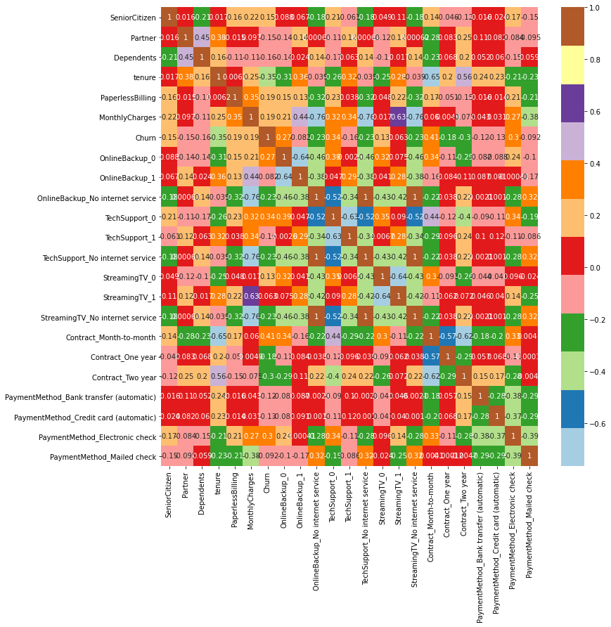

```python
plt.figure(figsize=(12,12))
sns.heatmap(df1.corr(),cmap='Paired',annot=True)
```

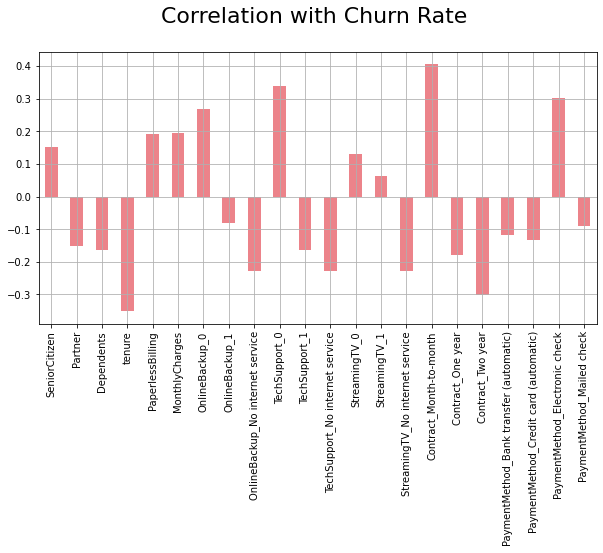

```python
df2 = df1[['SeniorCitizen', 'Partner', 'Dependents','tenure','PaperlessBilling','MonthlyCharges','OnlineBackup_0', 'OnlineBackup_1',
       'OnlineBackup_No internet service', 'TechSupport_0', 'TechSupport_1',
       'TechSupport_No internet service', 'StreamingTV_0', 'StreamingTV_1',
       'StreamingTV_No internet service','Contract_Month-to-month',
          'Contract_One year','Contract_Two year','PaymentMethod_Bank transfer (automatic)',
          'PaymentMethod_Credit card (automatic)','PaymentMethod_Electronic check','PaymentMethod_Mailed check']]

correlations = df2.corrwith(df1.Churn)
correlations = correlations[correlations!=1]
correlations.plot.bar(
        figsize = (10, 5),
        fontsize = 10,
        color = '#ec838a',
        rot = 45, grid = True)
plt.title('Correlation with Churn Rate \n',
horizontalalignment="center", fontstyle = "normal",
fontsize = "22", fontfamily = "sans-serif")
plt.xticks(rotation = 90)
plt.show()
```

```python
By using above corelation map we can conclude factors influence the churn
Result:
    1. Customers who owned the contract_Month_to_month, their churn rate is highly positive is 0.41
    2. secondly who doesn't have 'technical support', rate is 0.33
    3. thirdly who are using payment method as Electronic Check: rate is 0.30
    4. Who doesn't have online backup: 0.26
    5. paperless billing and monthly charges: 0.19, 0.18
    6. Senior citizen and who doesn't have straming tv : 0.15, 0.12
    7. who has streaming tv,churn rate least and < 1 i.e 0.06
```